# Analysis

Charlie Bayne

2022-08-15

# Goal

The goal of this experiment is to see the differences in global gene expression upon addition of tryptophan.

We have noted that this halts activity of clbP via the activity based probe, but the mechanism is still unclear. Hopefully, this study will allow us to see if this effect is at the transcriptional level.

# Methods

RNA seq was done in Andy’s lab.

# RNA Seq Procesing

## Intial Method

First we need to check to make sure that the RNA seq data produced good reads. We can do that using fastqc as follows.

```bash
fastqc Fastq/*
mkdir Fastq/fastqc
mv Fastq/*fastqc* Fastq/fastqc
```

Next, we need to build an index to use with the bowtie2 aligner. Here the strain of E.coli that we used for our experiments was ATCC_25922, so we are using that genome as the reference

Note that the first time I tried this I used the genome sequencing results from ATCC one codex. I figured that this would be the way to go because they do assemblies with a combination of nanopore and Illumina (i thought the long reads probably lead to a better assembly than the 2013 one provided by NCBI). The problem with this was that the annotation file was in a gbk format, and I couldn’t figure out how to get it into a gtf file to use with featureCounts.

I thought that I would be able to use bp_genbank2gff.pl, but this didn’t format the file correctly.

As a result I decided to just start over using files downloaded from NCBI (refseq). Hopefully this will fix the problems that I was having.

```bash
bowtie2-build --threads 8 -f GCF_000401755.1_Escherichia_coli_ATCC_25922_genomic.fna ATCC_25922_bowtie2_index/ATCC_25922
```

```bash
conda activate rnaseq

cd Fastq

#could have done this in a loop but it was easier to just do it for each sample independently.

prefix="DFE_AAOSRB_1_"
postfix="_HFNCCDRX2.UDI"
ext="_noribo_clean.fastq.gz"


bowtie2 -x ../ATCC_25922_bowtie2_index/ATCC_25922  -1 $prefix"1"$postfix$"425"$ext -2 $prefix"2"$postfix$"425"$ext -p 8 -S AAO.sam


prefix="DFE_ABOSRB_1_"
postfix="_HFNCCDRX2.UDI"
ext="_noribo_clean.fastq.gz"


bowtie2 -x ../ATCC_25922_bowtie2_index/ATCC_25922  -1 $prefix"1"$postfix$"426"$ext -2 $prefix"2"$postfix$"426"$ext -p 8 -S ABO.sam

prefix="DFE_ACOSRB_1_"
postfix="_HFNCCDRX2.UDI"
ext="_noribo_clean.fastq.gz"


bowtie2 -x ../ATCC_25922_bowtie2_index/ATCC_25922  -1 $prefix"1"$postfix$"427"$ext -2 $prefix"2"$postfix$"427"$ext -p 8 -S ACO.sam

prefix="DFE_ADOSRB_1_"
postfix="_HFNCCDRX2.UDI"
ext="_noribo_clean.fastq.gz"


bowtie2 -x ../ATCC_25922_bowtie2_index/ATCC_25922  -1 $prefix"1"$postfix$"468"$ext -2 $prefix"2"$postfix$"468"$ext -p 8 -S ADO.sam


prefix="DFE_AEOSRB_1_"
postfix="_HFNCCDRX2.UDI"
ext="_noribo_clean.fastq.gz"


bowtie2 -x ../ATCC_25922_bowtie2_index/ATCC_25922  -1 $prefix"1"$postfix$"429"$ext -2 $prefix"2"$postfix$"429"$ext -p 8 -S AEO.sam


prefix="DFE_AFOSRB_1_"
postfix="_HFNCCDRX2.UDI"
ext="_noribo_clean.fastq.gz"


bowtie2 -x ../ATCC_25922_bowtie2_index/ATCC_25922  -1 $prefix"1"$postfix$"430"$ext -2 $prefix"2"$postfix$"430"$ext -p 8 -S AFO.sam
```

Okay, now we have .SAM files for each of the samples where the reads have been mapped to the reference genome. Now we need to convert these to binary (BAM) files using SAM tools. We can do that as follows:

```bash
cd Fastq


samtools view -S -b -@ 8 AAO.sam > AAO.bam
samtools view -S -b -@ 8 ABO.sam > ABO.bam
samtools view -S -b -@ 8 ACO.sam > ACO.bam
samtools view -S -b -@ 8 ADO.sam > ADO.bam
samtools view -S -b -@ 8 AEO.sam > AEO.bam
samtools view -S -b -@ 8 AFO.sam > AFO.bam
```

Now that we have the BAM files, we need to sort them by chromosome position so they are compatible with genome viewers. We can do that as described below:

```bash
cd Fastq

samtools sort AAO.bam -o AAO.sorted.bam -@ 8
samtools sort ABO.bam -o ABO.sorted.bam -@ 8
samtools sort ACO.bam -o ACO.sorted.bam -@ 8
samtools sort ADO.bam -o ADO.sorted.bam -@ 8
samtools sort AEO.bam -o AEO.sorted.bam -@ 8
samtools sort AFO.bam -o AFO.sorted.bam -@ 8
```

Now that they are sorted, we need to make indexes so that we can extract alignments overlapping particular genomic regions. Also, this will be required to view these files in genome browsers like IGV.

```bash
cd Fastq

samtools index -@ 8 AAO.sorted.bam
samtools index -@ 8 ABO.sorted.bam
samtools index -@ 8 ACO.sorted.bam
samtools index -@ 8 ADO.sorted.bam
samtools index -@ 8 AEO.sorted.bam
samtools index -@ 8 AFO.sorted.bam
```

Now we need to actually extract the genes and the counts from each sample. We can do this using featureCounts from subread

Is this data stranded? I asked Andy and it seems like it is probably not.

Note that this data is paired end so the -p parameter is included.

```bash
cd Fastq

featureCounts -a ../GCF_000401755.1_Escherichia_coli_ATCC_25922_genomic.gtf -o rna_seq.counts *.sorted.bam -T 8 -p -t gene
```

Note that the first time I tired this command I didn’t specify -t gene, and that meant that it defaulted to looking for exons in my gtf file. Only 72 features were labeled as exons, looking at the file showed that the features tended to be labeled as gene, hence the -t gene flag. This resulted in ~5000 features and > 90% successfully assigned alignments. See RNA_sea.counts.summary for more information.

I looked at IGV to see the read pileups around the colibactin island. Unfortunately, it looks like the colibactin island is split across different contigs, so I will plan to reprocess the RNA seq data using a different reference genome.

## Final Method

I decided to rerun the data using the ATCC reference genome. I think this is the better way to go because it seems to be a higher quality genome (generated more recently using a combination of short and long read sequencing technology-ultimately resulting in only 5 contigs for a strain that has 2 x plasmids). This should allow us to look at the genomic features without splitting them across contigs.

```bash
#Activating rnaseq environment
conda activate rnaseq
cd ATCC
#Building the index using ATCC genome
bowtie2-build --threads 8 -f Escherichia_coli_ATCC_25922.fasta bowtie_index/ATCC_25922

#building the .sam files
for i in {425,426,427,468,429,420}
  do bowtie2 -x bowtie_index/ATCC_25922  -1 ../Fastq*_1_1*$i* -2 ../Fastq*_1_2*$i* -p 8 -S $i.sam;
  done


#renaming
mv 425.sam AAO.sam
mv 426.sam ABO.sam
mv 427.sam ACO.sam
mv 468.sam ADO.sam
mv 429.sam AEO.sam
mv 430.sam AFO.sam

#Converting to bam
samtools view -S -b -@ 8 AAO.sam > AAO.bam
samtools view -S -b -@ 8 ABO.sam > ABO.bam
samtools view -S -b -@ 8 ACO.sam > ACO.bam
samtools view -S -b -@ 8 ADO.sam > ADO.bam
samtools view -S -b -@ 8 AEO.sam > AEO.bam
samtools view -S -b -@ 8 AFO.sam > AFO.bam

#Sorting .bam
samtools sort AAO.bam -o AAO.sorted.bam -@ 8
samtools sort ABO.bam -o ABO.sorted.bam -@ 8
samtools sort ACO.bam -o ACO.sorted.bam -@ 8
samtools sort ADO.bam -o ADO.sorted.bam -@ 8
samtools sort AEO.bam -o AEO.sorted.bam -@ 8
samtools sort AFO.bam -o AFO.sorted.bam -@ 8


#Indexing .bam
samtools index -@ 8 AAO.sorted.bam
samtools index -@ 8 ABO.sorted.bam
samtools index -@ 8 ACO.sorted.bam
samtools index -@ 8 ADO.sorted.bam
samtools index -@ 8 AEO.sorted.bam
samtools index -@ 8 AFO.sorted.bam
```

ATCC only offered a .gbk annotation file, and I couldn’t figure out how to use it with feature counts so I decided to run the genome annotation my self. First I attempted this using PROKKA

```bash
#Running prokka
prokka Escherichia_coli_ATCC_25922.fasta

cd PROKKA_08082022
#Converting gff to gtf for feature counts. -F flag to retain all info
gffread *.gff -T -F -o PROKKA_08082022_all.gtf

cd ../
#running featureCounts
featureCounts -a PROKKA_08082022/PROKKA_08082022_all.gtf -o PROKKA_08082022/rna_seq_annotated.counts *.sorted.bam -T 8 -p -t transcript
```

Looking closer at this data, I found that prokka didn’t annotate the colibactin genes with the correct names. As I read more, I learned that prokka is a pretty good solution for annotation, but it’s primary focus is speed. Since we are only annotating one genome here, I decided to use the NCBI’s official genome annotation pipeline - pgap. From all accounts this offers superior annotation.

To do this I had to make an input.yaml file, and a submol.yaml file that contained information about the files to use in the pipeline and metadata respectively. See the [pgap wiki](https://github.com/ncbi/pgap/wiki/Input-Files) for more information.

```bash
cd ATCC/pgap

sudo ~/shared/settings/pgap/pgap.py -n -o annotation input.yaml --ignore-all-errors

# Changing from gff3 to gtf for feature count comparability
gffread annotation/annot.gff -T -F -o annot.gtf

cd ../
#Running featureCounts
featureCounts -a pgap/annot.gtf -o pgap/rna_seq.counts *.sorted.bam -T 8 -p -t transcript
```

# Analysis

Now we have the final processed data! Let’s analyze using DESEQ2.

```r
library(dplyr)
library(DESeq2)

cts = readr::read_delim("ATCC/pgap/rna_seq.counts",skip = 1) %>%
  rename_with(~ gsub(".sorted.bam","", .x)) %>%
  tibble::column_to_rownames("Geneid") %>%
  select(6:length(.)) %>%
  as.matrix()

md = readxl::read_excel("metadata.xlsx") %>%
  as.matrix()

dds = DESeqDataSetFromMatrix(countData = cts,
                              colData = md,
                              design= ~ Condition)
dds = DESeq(dds)

res = results(dds, contrast = c("Condition", "50mM_W","control"))

df = tibble(gene_id = res@rownames, padj = res$padj, log2FoldChange = res$log2FoldChange)
```

First let’s look at a PCA to get a idea of the overall data. This should let us know if the experiment generally worked as we would expect it to.

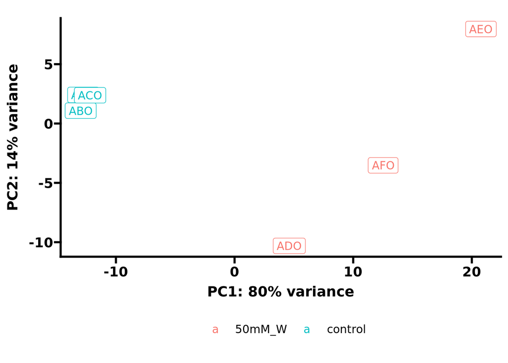

```r
library(ggplot2)
library(ggprism)
# Input is a matrix of log transformed values
 rld = rlog(dds, blind=T)

plotPCA(rld, intgroup="Condition")+
  theme_prism()+
  theme(legend.position = "bottom")+
  geom_label(aes(label = rld@colData$Sample_ID))
```

Now let’s look at a volcano plot to see how many differentially abundant genes there are.

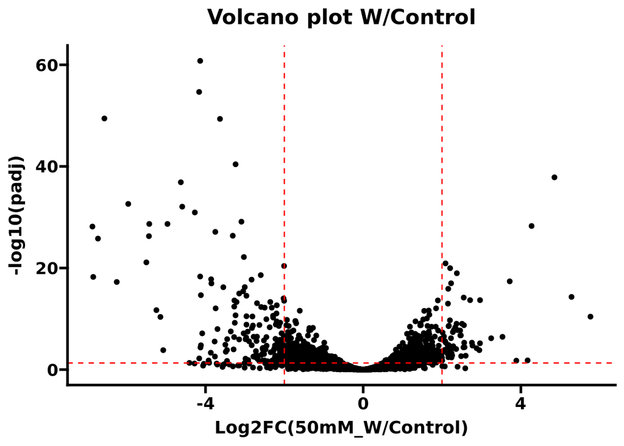

```r
library(ggplot2)
library(ggprism)

p1 = df %>%
  ggplot(aes(log2FoldChange,-log10(padj)))+
  geom_point()+
  geom_hline(yintercept = -log10(0.05),linetype = "dashed",color = "red")+
  geom_vline(xintercept = 2,linetype = "dashed", color = "red")+
  geom_vline(xintercept = -2,linetype = "dashed", color = "red")+
  theme_prism()+
  xlab("Log2FC(50mM_W/Control)")+
  ggtitle("Volcano plot W/Control")

p1
```

What are these genes though? Let’s look at a table of them sorted by those most up-regulated in response to the addition of tryptophan.

```r
library(stringr)
sig = df %>%
  filter(padj <= 0.005) %>%
  filter(log2FoldChange >= 2 | log2FoldChange <= -2)

library(rtracklayer)
gtf = import("ATCC/pgap/annot.gtf") %>%
  as.data.frame() %>%
  filter(type == "CDS")


up = inner_join(gtf,sig,by = c("transcript_id" = "gene_id")) %>%
  select(gene_id,gene,product,go_process,padj,log2FoldChange) %>%
  arrange(-log2FoldChange)

DT::datatable(up)
```

|  | gene_id | gene | product | go_process | padj | log2FoldChange |
| --- | --- | --- | --- | --- | --- | --- |
| 1 |  | cusB | Cu(+)/Ag(+) efflux RND transporter periplasmic adaptor subunit CusB |  | 3.78541538021012e-11 | 5.76574974388325 |
| 2 |  | cusA | Cu(+)/Ag(+) efflux RND transporter permease subunit CusA |  | 4.91019868947529e-15 | 5.28523246075765 |
| 3 |  | tnaA | tryptophanase | tryptophan metabolic process\|0006568\|\|IEA | 1.41827519815548e-38 | 4.85256585439851 |
| 4 |  | asnA | aspartate--ammonia ligase | asparagine biosynthetic process\|0006529\|\|IEA | 5.40883583437672e-29 | 4.27181428313455 |
| 5 |  | cusF | Cu(+)/Ag(+) efflux RND transporter periplasmic metallochaperone CusF |  | 4.22721417608519e-18 | 3.71761851208035 |
| 6 |  | cusC | Cu(+)/Ag(+) efflux RND transporter outer membrane channel CusC |  | 3.55809593988816e-07 | 3.53384509556275 |
| 7 |  | cusR | copper response regulator transcription factor CusR |  | 6.76511771522586e-07 | 3.24644793103886 |
| 8 |  | fimI | type 1 fimbrial protein |  | 2.15307413683397e-14 | 2.9644497201728 |
| 9 |  | copA | copper-exporting P-type ATPase CopA | cation transport\|0006812\|\|IEA | 6.62638574024763e-06 | 2.96299427118046 |
| 10 |  | nirC | nitrite transporter NirC | transmembrane transport\|0055085\|\|IEA | 0.00014830984304521 | 2.94661526948788 |

[output cut: 162 more lines]

**Table 1** Here we can see the list sorted by genes most up-regulated when 50mM tryptophan was added. We can see that tryptophanase is the third most up-regulated gene- unsurprisingly when you have more tryptophan present E.coli needs to break it down more. This suggests that the experiment and RNA seq were technical successes.

Interestingly, genes in the cus operon are most up-regulated. This is particularly interesting because [copper is required for colibactin to form cross-links with DNA](https://doi.org/10.1038/s41557-019-0317-7). Perhaps there could be some connection there?

Copper could be a co-factor for clbP activity. If this was the case, than one would expect that an increase of copper efflux in the periplasm would reduce the amount of copper available for clbP activity, thus leading the the observed results of reduced activity via the activity based probe.

Alternatively, perhaps the Cus copper efflux system could be exporting pre-colibactin/colibactin out of the periplasm (including the activity based probe). From the literature I have read it seems like the Cus system is very specific for Cu and Ag, but the way that colibactin is exported from the periplasm to extra-cellular space has not been described yet.

The logic behind why the addition of tryptophan would be increasing the need for copper efflux is not entirely clear to me. It has been reported that under limiting amino acid conditions copper efflux is increased in order to to protect Iron-Sulfur cluster enzymes [here](https://doi.org/10.1128/JB.00543-13). They report that this is due to the absence of methionine which is a key intracellular Cu(I) chelator. Methionine’s absence contributed to the elevation of Cu(I) under a reduced environment of anaerobic growth. I am wondering if it would be possible that increased tryptophan concentrations led to a corresponding increase in methionine uptake and the correlated reduction in intracellular concentrations ultimately leading to copper toxicity and the need to increase efflux.

I think to see whether the cus operon is involved in the effects of tryptophan on clbP activity we need to knock out cusA and see if we still get a reduction in clbP activity upon adding tryptophan.

Now lets see what genes were more up-regulated in the controls (down-regulated upon tryptophan )

```r
down = up%>%
  arrange(log2FoldChange)

DT::datatable(down)
```

|  | gene_id | gene | product | go_process | padj | log2FoldChange |
| --- | --- | --- | --- | --- | --- | --- |
| 1 |  | yfdX | YfdX family protein |  | 6.99187250871494e-29 | -6.86889422575173 |
| 2 |  | safA | two-component system connector SafA |  | 5.72915427238086e-19 | -6.84832606184847 |
| 3 |  | ydeO | acid stress response transcriptional regulator YdeO |  | 1.62849063270512e-26 | -6.72792382566063 |
| 4 |  | frc | formyl-CoA transferase | response to toxic substance\|0009636\|\|IEA,oxalate catabolic process\|0033611\|\|IEA | 3.65931610295267e-50 | -6.5654808884845 |
| 5 |  |  | hypothetical protein |  | 5.66388101544053e-18 | -6.25175757993235 |
| 6 |  | yfdV | transporter YfdV |  | 2.41757368413654e-33 | -5.96015572596745 |
| 7 |  | oxc | oxalyl-CoA decarboxylase | oxalate catabolic process\|0033611\|\|IEA | 7.76166743214749e-22 | -5.50062003008778 |
| 8 |  | hisL | his operon leader peptide | histidine biosynthetic process\|0000105\|\|IEA | 5.42744393696104e-27 | -5.43508115265983 |
| 9 |  | emrK | multidrug efflux MFS transporter periplasmic adaptor subunit EmrK |  | 2.12722829506715e-29 | -5.42676500007308 |
| 10 |  | emrY | multidrug efflux MFS transporter permease subunit EmrY |  | 1.97337406639891e-12 | -5.24582877097219 |

[output cut: 162 more lines]

**Table 2.** Notably, the tryptophan operon is significantly down-regulated in response to W, unsurprisingly when tryptophan is added in access the cells don’t need to make it as much(even though it isn’t the most down regulated i.e. trpD log2FC of -4 - 19th most down). Once again, this shows that the experiment was a technical success.

What about the genes directly related to colibactin production? We didn’t see any of those on the lists. Since the activity based probe should be measuring clbP activity I would expect clbP gene expression to be downregulated if the effect of tryptophan is at the transcriptional level.

To see the differences in gene expression, let’s take a look at the read pileups across the entire island.

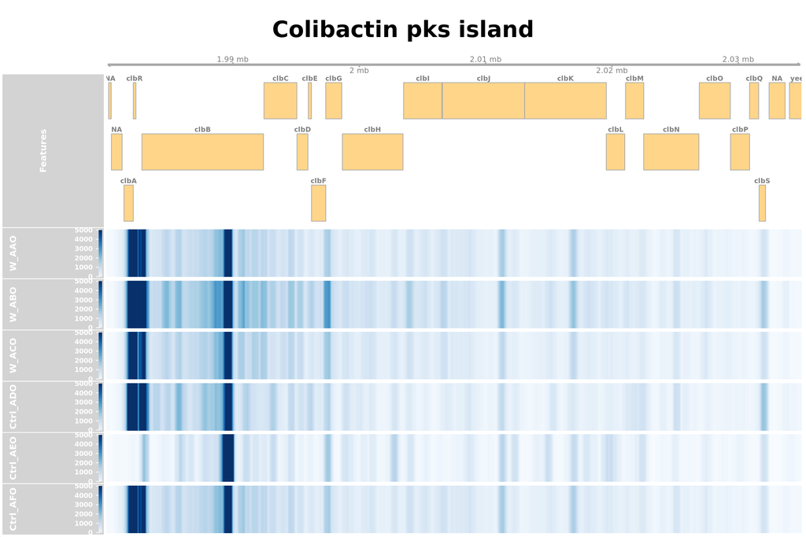

```r
library("Gviz")
options(ucscChromosomeNames=FALSE)

gm = GeneRegionTrack("ATCC/pgap/annot.gtf", chromosome="1dad9b1ccf124c63_1",genome = "ATCC/pgap/Escherichia_coli_ATCC_25922.fasta",gene = "gene_name",geneSymbol = TRUE,symbol = "gene_name",name = "Features")

gtrack = GenomeAxisTrack(showTitle=TRUE,name = "Colibactin pks island")

gm = gm[feature(gm) %in% c("CDS")]

AAO = "ATCC/AAO.sorted.bam"
ABO = "ATCC/ABO.sorted.bam"
ACO = "ATCC/ACO.sorted.bam"
ADO = "ATCC/ADO.sorted.bam"
AEO = "ATCC/AEO.sorted.bam"
AFO = "ATCC/AAO.sorted.bam"

AAO_track = DataTrack(range = AAO,
                                type = "heatmap",
                                name = "W_AAO",
                                window = -1,
                                chromosome = "1dad9b1ccf124c63_1")
ABO_track = DataTrack(range = ABO,
                                type = "heatmap",
                                name = "W_ABO",
                                window = -1,
                                chromosome = "1dad9b1ccf124c63_1")
ACO_track = DataTrack(range = ACO,
                                type = "heatmap",
                                name = "W_ACO",
                                window = -1,
                                chromosome = "1dad9b1ccf124c63_1")
ADO_track= DataTrack(range = ADO,
                                type = "heatmap",
                                name = "Ctrl_ADO",
                                window = -1,
                                chromosome = "1dad9b1ccf124c63_1")
AEO_track = DataTrack(range = AEO,
                                type = "heatmap",
                                name = "Ctrl_AEO",
                                window = -1,
                                chromosome = "1dad9b1ccf124c63_1")
AFO_track = DataTrack(range = AFO,
                                type = "heatmap",
                                name = "Ctrl_AFO",
                                window = -1,
                                chromosome = "1dad9b1ccf124c63_1")

plotTracks(list(gtrack,gm,AAO_track,ABO_track,ACO_track,ADO_track,AEO_track,AFO_track),from=1980000, to=2035000,transcriptAnnotation="symbol",ylim =c(0,5000),just.group = "above",title.width = 2,main = "Colibactin pks island")
```

Let’s make a function to make a plot like the one above easily and then use it to look at the Cus operon in a similar way.

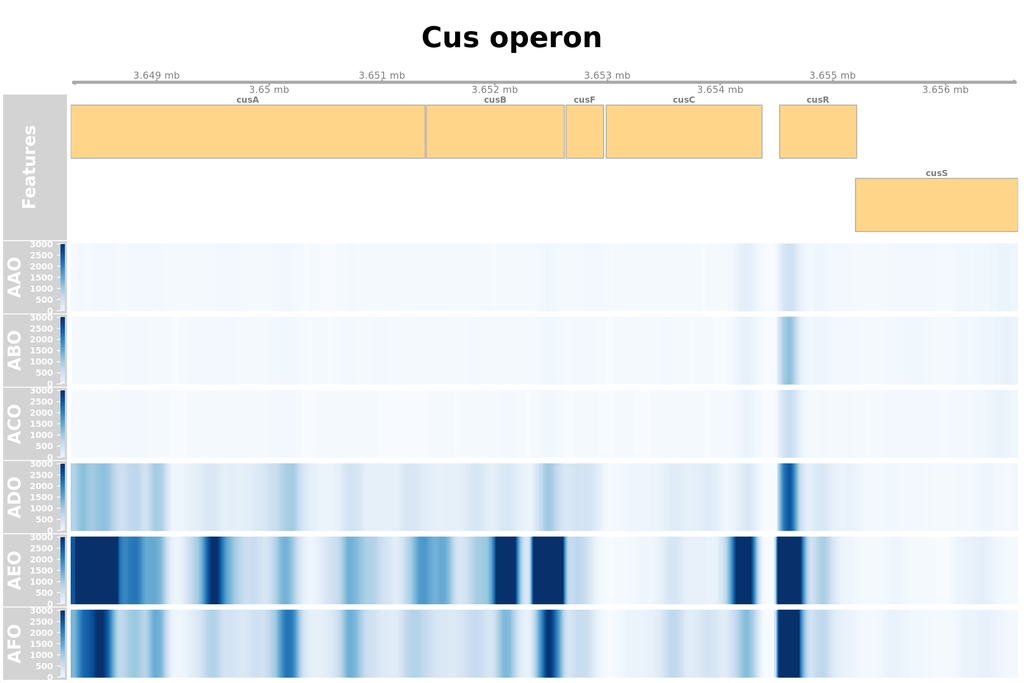

```r
plot_genome_features = function(gtf_file,start_gene,end_gene,sorted.bam_files,scale_height,title){
  #Setting options
options(ucscChromosomeNames=FALSE)
  #importing gtf file to extract coordinates from
gtf_data = rtracklayer::import(gtf_file) %>%
  as.data.frame() %>%
  filter(type == "CDS")
# determining start and end coords
df = gtf_data %>%
  filter(gene_name %in% c(start_gene,end_gene))
start = min(df$start)
end = max(df$end)
#What chromosome?
chromosome = unique(as.vector(df$seqnames))
#Genome annotation
ga = GeneRegionTrack(gtf_file,
                     chromosome=chromosome,
                     gene = "gene_name",
                     geneSymbol = TRUE,
                     ymbol = "gene_name",
                     name = "Features",
                     labelPos="above")
#gene axis
gtrack = GenomeAxisTrack(name = title)

#bamlist
bam_list = purrr::map(sorted.bam_files, .f = function(.x){unlist(DataTrack(range = .x,
                                type = "heatmap",
                                name = gsub(".*/","",.x) %>% gsub(".sorted.bam","",.),
                                window = -1,
                                chromosome = "1dad9b1ccf124c63_1"))})

tracks = list(gtrack,ga,unlist(bam_list))

plotTracks(c(gtrack,ga,bam_list),from=start, to=end,transcriptAnnotation="symbol",ylim =c(0,scale_height),just.group = "above",main = title)

}


plot_genome_features("ATCC/pgap/annot.gtf",
                     start_gene = "cusA",
                     end_gene = "cusS",
                     sorted.bam_files = c("ATCC/AAO.sorted.bam",
                                          "ATCC/ABO.sorted.bam",
                                          "ATCC/ACO.sorted.bam",
                                          "ATCC/ADO.sorted.bam",
                                          "ATCC/AEO.sorted.bam",
                                          "ATCC/AFO.sorted.bam"),
                     scale_height = 3000,
                     title = "Cus operon")
```

Now lets look at functional profiles by looking at gene functions that were up regulated in response to tryptophan.

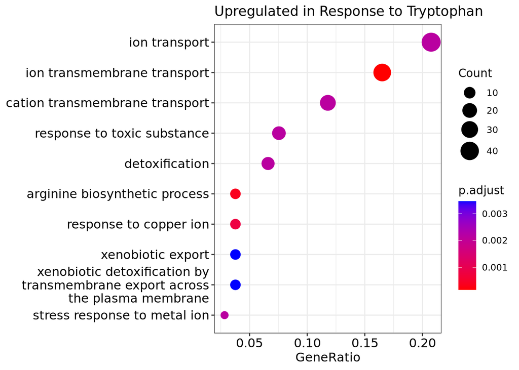

```r
up = df %>%
  filter(padj <= 0.005) %>%
  filter(log2FoldChange > 0)

library(rtracklayer)
gtf = import("ATCC/pgap/annot.gtf") %>%
  as.data.frame() %>%
  filter(type == "CDS")


diff = inner_join(gtf,up,by = c("transcript_id" = "gene_id"))


library(clusterProfiler)
library("org.EcK12.eg.db")

gene= diff$gene_name

gene.df = bitr(gene, fromType = "SYMBOL",
        toType = "ENTREZID",
        OrgDb = org.EcK12.eg.db)

ego  = enrichGO(gene = gene.df$ENTREZID,
                OrgDb = org.EcK12.eg.db,
                keyType = 'ENTREZID',
                ont = "ALL",
                pAdjustMethod = "fdr",
                pvalueCutoff  = 0.01,
                qvalueCutoff  = 0.05)

library(enrichplot)
dotplot(ego)+
  ggtitle("Upregulated in Response to Tryptophan")
```

**Figure 5.** Here we can see that ion transport is most up-regulated function. This is interesting because it seems related to the copper efflux up-regulation. Once again, why tryptophan would be increasing expression of genes with these functions is not immediately clear to me.

Now let’s do a network analysis. This will allow us to visualize all of the genes

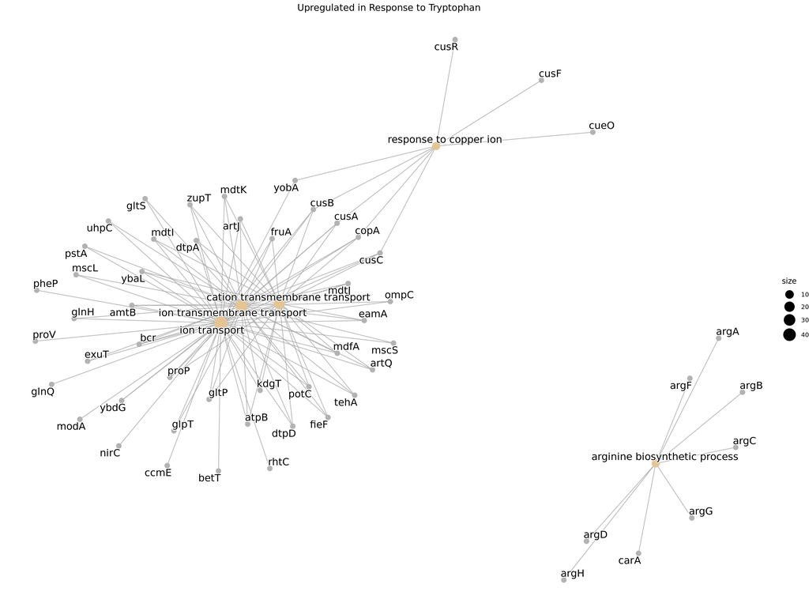

```r
edox = setReadable(ego, 'org.EcK12.eg.db', 'ENTREZID')

p1 = cnetplot(edox)+
  ggtitle("Upregulated in Response to Tryptophan")+
  theme(plot.title = element_text(hjust = 0.5))

p1
```

**Figure 6.** Here we can see the network of up-regulated genes by function. There are two discrete clusters, arginine bio-synthetic process and then ion transport cluster (composed of several sub-clusters).

Now let’s look at the genes that were most downregulated in tryptophan treated cells relative to control.

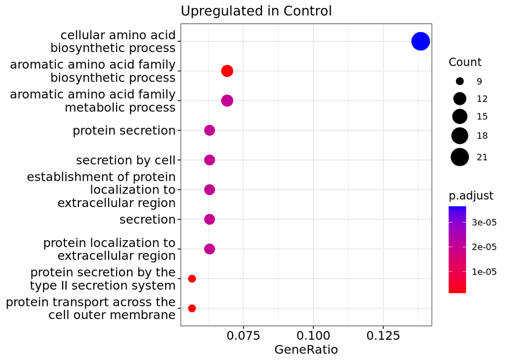

```r
down = df %>%
  filter(padj <= 0.005) %>%
  filter(log2FoldChange < 0)

library(rtracklayer)
gtf = import("ATCC/pgap/annot.gtf") %>%
  as.data.frame() %>%
  filter(type == "CDS")


diff = inner_join(gtf,down,by = c("transcript_id" = "gene_id"))


library(clusterProfiler)
library("org.EcK12.eg.db")

gene= diff$gene_name

gene.df = bitr(gene, fromType = "SYMBOL",
        toType = "ENTREZID",
        OrgDb = org.EcK12.eg.db)

ego  = enrichGO(gene = gene.df$ENTREZID,
                OrgDb = org.EcK12.eg.db,
                keyType = 'ENTREZID',
                ont = "BP",
                pAdjustMethod = "fdr",
                pvalueCutoff  = 0.01,
                qvalueCutoff  = 0.05)

library(enrichplot)
dotplot(ego)+
  ggtitle("Upregulated in Control")
```

**Figure 7.** Here we can see that the mot changed thing is cellular amino acids. This makes sense as the addition of tryptophan is bound to cause the cell to need to change its cellular amino acid pools. Interestingly there are also many more protein secretion systems that seem to be up-regulated.

Now let’s look at a network.

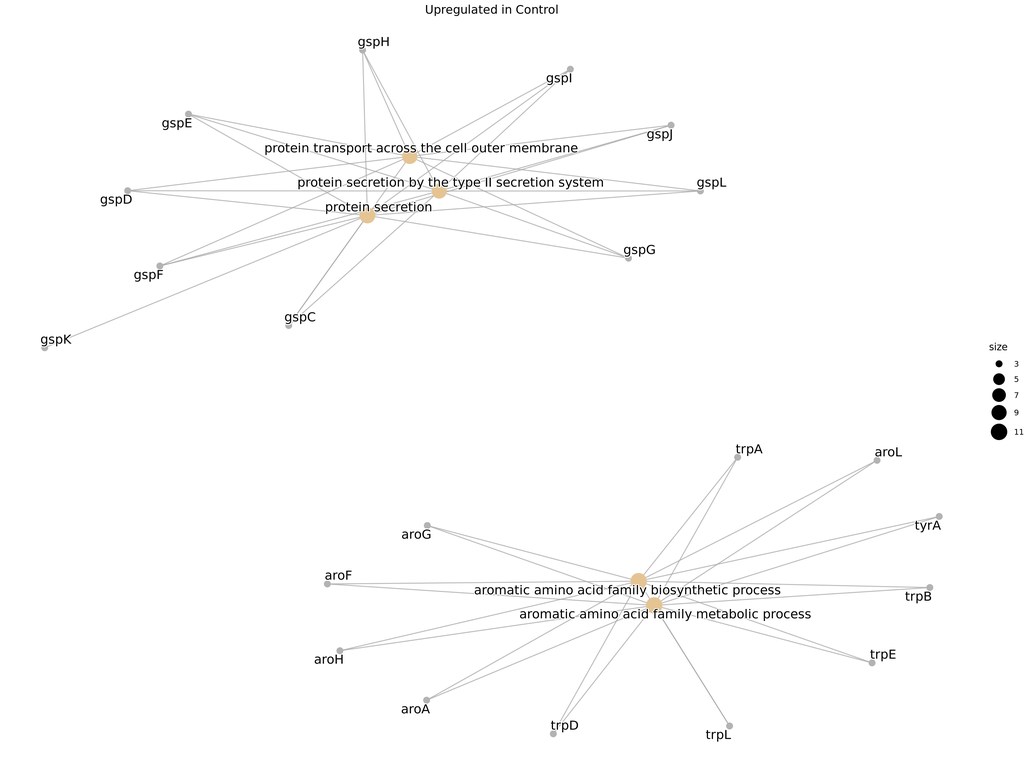

```r
edox = setReadable(ego, 'org.EcK12.eg.db', 'ENTREZID')

p1 = cnetplot(edox)+
  ggtitle("Upregulated in Control")+
  theme(plot.title = element_text(hjust = 0.5))

p1
```

**Figure 8.** Here we can see the genes. There ware two main clusters, a cluster having to do with aromatic amino acid biosynthesis, and another having to do with protein secretion.